# Chinese PhDs in the United States, Europe, and United Kingdom (1905-1962)

Episode 2: Tracing Chinese Doctors’ Backgrounds

Cécile Armand, Christian Henriot

2025-05-25

Abstract

# Introduction

This second script aims to analyze the background of Chinese PhDs using external data — specifically, the [China University Student Dataset (CUSD)](https://leecampbellgroup.blog/projects/china-university-student-dataset-cusd-project/) compiled by the Lee-Campbell Research Group. This comprehensive dataset offers detailed information on the social and geographic family backgrounds of nearly 300,000 Chinese students who enrolled in Chinese universities during the late Qing and Republican periods. It includes critical information not provided in the original dissertation catalogs—most notably, students’ place and date of birth, gender, and the educational institutions they attended both in China and abroad. Since the dataset is not yet publicly available, we provide only the subset resulting from the match with our initial dataset of Chinese PhDs.

# Sub-Dataset

Of the 4,683 individuals in the main dataset, 3,716 (79.4%) were successfully matched with entries in the CUSDOS dataset. Match coverage was highest for those who studied in the United States (83.4%), followed closely by the United Kingdom (83.2%) and Europe (71.3%).

```r
# load dataset

library(readr)
phd_cus_all <- read_delim("Data/phd_cus_all.csv",
    delim = ";", escape_double = FALSE, trim_ws = TRUE)
```

```r
library(tidyverse)
phd_cus_all %>% group_by(Region) %>% count(sort = TRUE)
```

| Region | n |
| --- | --- |
| USA | 2315 |
| EUR | 1113 |
| UK | 288 |

|  | Matched in CUSD-OS | (%) |
| --- | --- | --- |
| USA | 2,315 | 83.4% |
| Europe | 1,113 | 71.3% |
| UK | 288 | 83.2% |
| Total | 3,716 | 79.4% |

It is important to note that biographical information—such as gender and provincial origin—is not systematically available. As a result, even when a Chinese PhD was successfully matched with a corresponding record in the CUSD, their biographical data may still be incomplete.

```r
colSums(is.na(phd_cus_all))
```

```
##                        ID                    NameZH                University
##                         0                         0                         0
##              cus_Univ_Eng          cus_Univ_For_ZhT                     IDCUS
##                       936                       591                         0
##                cus_NameZH           cus_NameZH_uniq          cus_Name_Alt_Eng
##                         0                      3716                      3715
##           cus_Name_Alt_Zh                    cus_Zi         cus_Birth_Loc_ZhT
##                      3632                      3716                      3699
##        cus_Birth_Prov_ZhT                cus_Gender        cus_Univ_China_ZhT
##                      3007                      1445                      2855
##           cus_Univ_For_Py                  cus_City                   cus_Lat
##                      3341                      1021                      1197
##                  cus_Long           cus_Country_Eng     cus_Discipline_Level2
##                      1211                         0                      2524
## cus_Discipline_Level2_ZhT     cus_Discipline_Level1 cus_Discipline_Level1_ZhT
##                      2524                      2371                      2372
##     cus_Discipline_Level0 cus_Discipline_Level0_ZhT           cus_Code_Level1
##                      1828                      1829                      1828
##                 cus_Major             cus_BirthYear             cus_DeathYear
##                      1817                      3716                      3716
##           cus_NameZH_Uniq       cus_Univ_China_Orig                    Region
##                      3714                      3099                         0
##     cus_Birth_Country_ZhT
##                      3716
```

```r
sapply(phd_cus_all, function(x) sum(is.na(x)) / length(x) * 100)
```

```
##                        ID                    NameZH                University
##                   0.00000                   0.00000                   0.00000
##              cus_Univ_Eng          cus_Univ_For_ZhT                     IDCUS
##                  25.18837                  15.90420                   0.00000
##                cus_NameZH           cus_NameZH_uniq          cus_Name_Alt_Eng
##                   0.00000                 100.00000                  99.97309
##           cus_Name_Alt_Zh                    cus_Zi         cus_Birth_Loc_ZhT
##                  97.73950                 100.00000                  99.54252
##        cus_Birth_Prov_ZhT                cus_Gender        cus_Univ_China_ZhT
##                  80.92034                  38.88590                  76.82992
##           cus_Univ_For_Py                  cus_City                   cus_Lat
##                  89.90850                  27.47578                  32.21206
##                  cus_Long           cus_Country_Eng     cus_Discipline_Level2
##                  32.58881                   0.00000                  67.92250
## cus_Discipline_Level2_ZhT     cus_Discipline_Level1 cus_Discipline_Level1_ZhT
##                  67.92250                  63.80517                  63.83208
##     cus_Discipline_Level0 cus_Discipline_Level0_ZhT           cus_Code_Level1
##                  49.19268                  49.21959                  49.19268
##                 cus_Major             cus_BirthYear             cus_DeathYear
##                  48.89666                 100.00000                 100.00000
##           cus_NameZH_Uniq       cus_Univ_China_Orig                    Region
##                  99.94618                  83.39612                   0.00000
##     cus_Birth_Country_ZhT
##                 100.00000
```

As shown above, gender information is missing for approximately 39% of individuals, the province of birth is unreported in 81% of cases, and the university previously attended in China is unknown for over 83% of the sample. Information regarding gender, geographical origin, and previous university attended in China is available for 359 individuals, representing less than 10% of the initial population:

```r
phd_cus_complete <- phd_cus_all[complete.cases(phd_cus_all[, c("cus_Gender", "cus_Birth_Prov_ZhT", "cus_Univ_China_Orig")]), ]

phd_cus_complete
```

|  | ID | NameZH | University | cus_Univ_Eng | cus_Univ_For_ZhT | IDCUS | cus_NameZH | cus_NameZH_uniq | cus_Name_Alt_Eng | cus_Name_Alt_Zh | cus_Zi | cus_Birth_Loc_ZhT | cus_Birth_Prov_ZhT | cus_Gender | cus_Univ_China_ZhT | cus_Univ_For_Py | cus_City | cus_Lat | cus_Long | cus_Country_Eng | cus_Discipline_Level2 | cus_Discipline_Level2_ZhT | cus_Discipline_Level1 | cus_Discipline_Level1_ZhT | cus_Discipline_Level0 | cus_Discipline_Level0_ZhT | cus_Code_Level1 | cus_Major | cus_BirthYear | … |
| --- | --- | --- | --- | --- | --- | --- | --- | --- | --- | --- | --- | --- | --- | --- | --- | --- | --- | --- | --- | --- | --- | --- | --- | --- | --- | --- | --- | --- | --- | --- |
| 4 | 1024 | 趙世傑 | Stanford University | Stanford University | 斯坦福大學 | 41237 | 趙世傑 | NA | NA | NA | NA | NA | 遼寧 | 男 | 中央大學 | NA | Stanford | 374274.0000 | -1221711.0000 | United States | NA | NA | NA | NA | NA | NA | NA | NA | NA | … |
| 7 | 669 | 江美貞 | University of Pennsylvania | University of Pennsylvania | 賓夕法尼亞大學 | 47366 | 江美貞 | NA | NA | 陳江美貞 | NA | 上海 | 江蘇 | 女 | 東吳大學 | NA | Philadelphia | 399526.0000 | -751652.0000 | United States | NA | NA | NA | NA | NA | NA | NA | NA | NA | … |
| 8 | 1027 | 趙大祥 | Purdue University | Purdue University | 普渡大學 | 41474 | 趙大祥 | NA | NA | NA | NA | NA | 江蘇 | 男 | 中央大學 | NA | West Lafayette | 404258.0000 | -86908.0000 | United States | NA | NA | NA | NA | NA | NA | NA | NA | NA | … |
| 9 | 2680 | 嚴希孟 | University of Illinois | Illinois State University | 伊利諾斯州立大學 | 4406 | 嚴希孟 | NA | NA | NA | NA | NA | 江蘇 | 男 | 交通大學 | NA | Normal | 405199.0000 | -889936.0000 | United States | NA | NA | NA | NA | NA | NA | NA | NA | NA | … |
| 10 | 1619 | 朱家珍 | University of Illinois | Illinois State University | 伊利諾斯州立大學 | 16830 | 朱家珍 | NA | NA | 康朱家珍 | NA | NA | 浙江 | 女 | 滬江大學 | NA | Normal | 405199.0000 | -889936.0000 | United States | NA | NA | NA | NA | NA | NA | NA | NA | NA | … |
| 12 | 327 | 胡適 | Columbia University | Columbia University | 哥倫比亞大學 | 37213 | 胡適 | NA | NA | NA | NA | NA | 安徽 | 男 | 中國學院 | NA | New York City | 407306.0000 | -739866.0000 | United States | NA | NA | NA | NA | NA | NA | NA | NA | NA | … |
| 14 | 82 | 趙世澤 | Columbia University | Columbia University | 哥倫比亞大學 | 41238 | 趙世澤 | NA | NA | NA | NA | NA | 廣西 | 男 | 華中大學 | NA | New York City | 407306.0000 | -739866.0000 | United States | NA | NA | NA | NA | NA | NA | NA | NA | NA | … |
| 15 | 366 | 俞秀文 | Columbia University | Columbia University | 哥倫比亞大學 | 50200 | 俞秀文 | NA | NA | 高俞秀文 | NA | NA | 江蘇 | 女 | 滬江大學 | NA | New York City | 407306.0000 | -739866.0000 | United States | NA | NA | NA | NA | NA | NA | NA | NA | NA | … |
| 21 | 2614 | 楊人濟 | Iowa State University | University of Iowa | 愛荷華大學 | 26134 | 楊人濟 | NA | NA | NA | NA | 上海 | 江蘇 | 男 | 中央大學 | NA | Iowa City | 416611.0000 | -915302.0000 | United States | NA | NA | NA | NA | Science | 科學 | SSC | Science | NA | … |
| 27 | 898 | 徐慶祥 | Cornell University | Cornell University | 康奈爾大學 | 18189 | 徐慶祥 | NA | NA | 張徐慶祥 | NA | NA | 江蘇 | 女 | 聖約翰大學 | NA | Ithaca | 424439.0000 | -764858.0000 | United States | NA | NA | NA | NA | NA | NA | NA | NA | NA | … |

[output cut: 349 more lines]

Nevertheless, we have obtained valuable information about the PhD holders that was not available in the original dissertation catalog.

# Gender

```r
phd_all_master %>% group_by(Sex) %>% count(sort = TRUE)
```

| Sex | n |
| --- | --- |
| NA | 4515 |
| Female | 198 |
| Male | 4 |

```r
phd_all_master %>% group_by(Region, Sex) %>% count() # by Region
```

| Region | Sex | n |
| --- | --- | --- |
| Europe | Female | 21 |
| Europe | NA | 1562 |
| UK | NA | 352 |
| USA | Female | 177 |
| USA | Male | 4 |
| USA | NA | 2601 |

# Generation

## Year of Birth

```r
phd_all_master %>% group_by(Birth_year_corr) %>% count(sort = TRUE)
```

| Birth_year_corr | n |
| --- | --- |
| NA | 2034 |
| 1919 | 133 |
| 1922 | 117 |
| 1917 | 114 |
| 1920 | 112 |
| 1918 | 107 |
| 1921 | 107 |
| 1923 | 96 |
| 1916 | 95 |
| 1915 | 81 |

[output cut: 51 more lines]

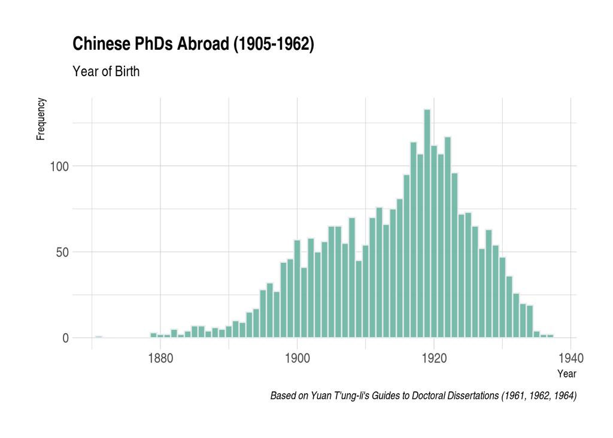

```r
phd_all_master %>% drop_na(Birth_year_corr) %>%
  ggplot( aes(x=Birth_year_corr)) +
  geom_histogram( binwidth=1, fill="#69b3a2", color="#e9ecef", alpha=0.9) +
  ggtitle("Bin size = 1") +
  theme_ipsum() +
  theme(
    plot.title = element_text(size=15)
  ) +
  labs(title = "Chinese PhDs Abroad (1905-1962)",
       subtitle = "Year of Birth",
       x = "Year",
       y = "Frequency",
       caption = "Based on Yuan T'ung-li's Guides to Doctoral Dissertations (1961, 1962, 1964)")
```

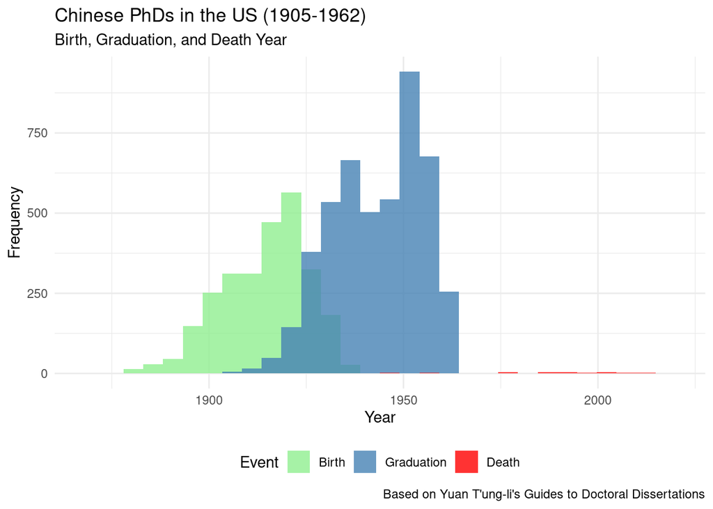

```r
# Reshape and convert
generation <- gather(phd_all_master, key = "Event", value = "Year", Birth_year_corr, Degree_Year, Death_year) %>%
  drop_na(Year) %>%
  mutate(Year = as.numeric(Year),
         Event = factor(Event, levels = c("Birth_year_corr", "Degree_Year", "Death_year")))

# Plot
ggplot(generation, aes(x = Year , fill = Event)) +
  geom_histogram(position = "identity", alpha = 0.8, bins = 30) +
  labs(title = "Chinese PhDs in the US (1905-1962)",
       subtitle = "Birth, Graduation, and Death Year",
       x = "Year",
       y = "Frequency",
       caption = "Based on Yuan T'ung-li's Guides to Doctoral Dissertations") +
  scale_fill_manual(
    values = c("Birth_year_corr" = "light green", "Degree_Year" = "steelblue", "Death_year" = "red"),
    labels = c("Birth", "Graduation", "Death")
  ) +
  theme_minimal() +
  theme(legend.position = "bottom")
```

## Age at Graduation

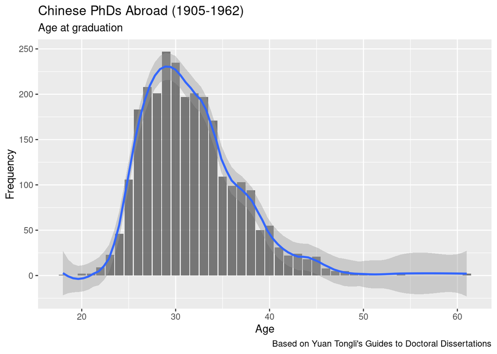

```r
phd_all_master %>% filter(!Birth_year_corr == "NA") %>% group_by(Age_Grad)  %>% count() %>%
  ggplot(aes(Age_Grad, n)) + geom_col(alpha = 0.8) + geom_smooth(span = .25) +
  labs(title = "Chinese PhDs Abroad (1905-1962)",
       subtitle = "Age at graduation",
       x = "Age",
       y = "Frequency",
       caption = "Based on Yuan Tongli's Guides to Doctoral Dissertations")
```

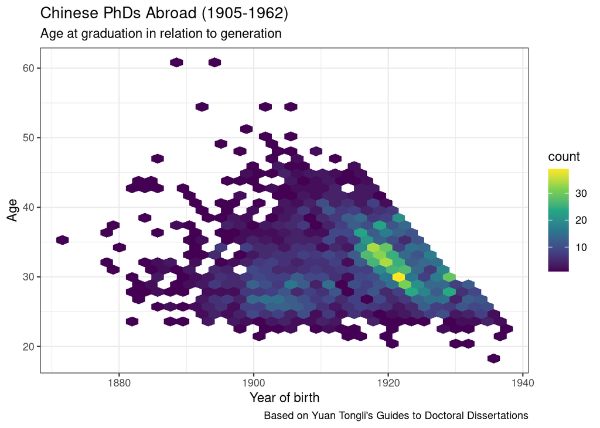

```r
ggplot(phd_all_master, aes(x=Birth_year_corr, y=Age_Grad) ) +
  geom_hex(bins = 35) +
  scale_fill_continuous(type = "viridis") +
  theme_bw() +
  labs(title = "Chinese PhDs Abroad (1905-1962)",
       subtitle = "Age at graduation in relation to generation",
       x = "Year of birth",
       y = "Age",
       caption = "Based on Yuan Tongli's Guides to Doctoral Dissertations")
```

# Birth Place

```r
phd_cus_all %>% group_by(cus_Birth_Prov_ZhT) %>% drop_na(cus_Birth_Prov_ZhT) %>%
  count(sort = TRUE) %>%
  mutate(percent = round(n/709*100, 2))
```

| cus_Birth_Prov_ZhT | n | percent |
| --- | --- | --- |
| 江蘇 | 180 | 25.39 |
| 浙江 | 125 | 17.63 |
| 廣東 | 71 | 10.01 |
| 福建 | 51 | 7.19 |
| 河北 | 37 | 5.22 |
| 安徽 | 35 | 4.94 |
| 湖南 | 35 | 4.94 |
| 湖北 | 33 | 4.65 |
| 四川 | 31 | 4.37 |
| 江西 | 24 | 3.39 |

[output cut: 14 more lines]

## By Region of Education

```r
## USA
phd_cus_USA_match %>% group_by(cus_Birth_Prov_ZhT) %>% count(sort = TRUE) %>% mutate(percent = round(n/2315*100, 2))
```

| cus_Birth_Prov_ZhT | n | percent |
| --- | --- | --- |
| NA | 1889 | 81.60 |
| 江蘇 | 121 | 5.23 |
| 浙江 | 69 | 2.98 |
| 廣東 | 44 | 1.90 |
| 福建 | 34 | 1.47 |
| 湖北 | 23 | 0.99 |
| 河北 | 22 | 0.95 |
| 安徽 | 21 | 0.91 |
| 湖南 | 19 | 0.82 |
| 四川 | 15 | 0.65 |

[output cut: 11 more lines]

```r
## United Kingdom
phd_cus_UK_match %>% group_by(cus_Birth_Prov_ZhT) %>% count(sort = TRUE) %>% mutate(percent = round(n/288*100, 2))
```

| cus_Birth_Prov_ZhT | n | percent |
| --- | --- | --- |
| NA | 229 | 79.51 |
| 浙江 | 15 | 5.21 |
| 廣東 | 9 | 3.12 |
| 江蘇 | 9 | 3.12 |
| 湖南 | 6 | 2.08 |
| 安徽 | 4 | 1.39 |
| 福建 | 4 | 1.39 |
| 四川 | 3 | 1.04 |
| 湖北 | 3 | 1.04 |
| 山東 | 2 | 0.69 |

[output cut: 4 more lines]

```r
## Europe
phd_cus_EUR_match %>% group_by(cus_Birth_Prov_ZhT) %>% count(sort = TRUE) %>% mutate(percent = round(n/1113*100, 2))
```

| cus_Birth_Prov_ZhT | n | percent |
| --- | --- | --- |
| NA | 889 | 79.87 |
| 江蘇 | 50 | 4.49 |
| 浙江 | 41 | 3.68 |
| 廣東 | 18 | 1.62 |
| 河北 | 15 | 1.35 |
| 四川 | 13 | 1.17 |
| 福建 | 13 | 1.17 |
| 江西 | 11 | 0.99 |
| 安徽 | 10 | 0.90 |
| 湖南 | 10 | 0.90 |

[output cut: 12 more lines]

## Flow Charts

```r
# load package
library(networkD3)

# select variables

birth_region <- phd_cus_all %>% select(cus_Birth_Prov_ZhT, Region) %>% na.omit()


# create links and compute weight

birth_region_link <- birth_region %>%
  rename(source = cus_Birth_Prov_ZhT, target = Region) %>%
  group_by(source, target) %>%
  count() %>%
  rename(value = "n")

# create nodes

birth_region_node <- data.frame(
  name=c(as.character(birth_region_link$source),
         as.character(birth_region_link$target)) %>% unique()
)


# Plot

birth_region_link$IDsource <- match(birth_region_link$source, birth_region_node$name)-1
birth_region_link$IDtarget <- match(birth_region_link$target, birth_region_node$name)-1

# Make the Network
p1 <- sankeyNetwork(Links = birth_region_link, Nodes = birth_region_node,
                   Source = "IDsource", Target = "IDtarget",
                   Value = "value", NodeID = "name",
                   fontSize = 14,
                   fontFamily = "Arial",
                   nodeWidth = 30,
                   sinksRight=FALSE)
p1
```

[interactive chart not shown]

# Prior Education in China

```r
phd_cus_all %>% drop_na(cus_Univ_China_ZhT) %>%
  group_by(cus_Univ_China_ZhT) %>%
  count(sort = TRUE) %>%
  mutate(percent = round(n/709*100, 2))
```

| cus_Univ_China_ZhT | n | percent |
| --- | --- | --- |
| 清華大學 | 147 | 20.73 |
| 中央大學 | 109 | 15.37 |
| 交通大學 | 64 | 9.03 |
| 金陵大學 | 51 | 7.19 |
| 燕京大學 | 43 | 6.06 |
| 北京大學 | 29 | 4.09 |
| 同濟大學 | 28 | 3.95 |
| 浙江大學 | 27 | 3.81 |
| 東吳大學 | 26 | 3.67 |
| 聖約翰大學 | 23 | 3.24 |

[output cut: 75 more lines]

## By Region of Education

```r
## USA
phd_cus_USA_match %>% drop_na(cus_Univ_China_ZhT) %>% group_by(cus_Univ_China_ZhT) %>% count(sort = TRUE) %>% mutate(percent = round(n/2315*100, 2))
```

| cus_Univ_China_ZhT | n | percent |
| --- | --- | --- |
| 清華大學 | 120 | 5.18 |
| 中央大學 | 84 | 3.63 |
| 交通大學 | 58 | 2.51 |
| 金陵大學 | 45 | 1.94 |
| 燕京大學 | 33 | 1.43 |
| 聖約翰大學 | 22 | 0.95 |
| 浙江大學 | 20 | 0.86 |
| 東吳大學 | 19 | 0.82 |
| 西南聯合大學 | 19 | 0.82 |
| 北京大學 | 15 | 0.65 |

[output cut: 51 more lines]

```r
## United Kingdom
phd_cus_UK_match %>% drop_na(cus_Univ_China_ZhT) %>% group_by(cus_Univ_China_ZhT) %>% count(sort = TRUE) %>% mutate(percent = round(n/288*100, 2))
```

| cus_Univ_China_ZhT | n | percent |
| --- | --- | --- |
| 清華大學 | 14 | 4.86 |
| 中央大學 | 13 | 4.51 |
| 燕京大學 | 6 | 2.08 |
| 交通大學 | 4 | 1.39 |
| 西南聯合大學 | 4 | 1.39 |
| 交通大學唐山工學院 | 3 | 1.04 |
| 浙江大學 | 3 | 1.04 |
| 金陵大學 | 3 | 1.04 |
| 上海醫學院 | 2 | 0.69 |
| 復旦大學 | 2 | 0.69 |

[output cut: 18 more lines]

```r
## Europe
phd_cus_EUR_match %>% drop_na(cus_Univ_China_ZhT) %>% group_by(cus_Univ_China_ZhT) %>% count(sort = TRUE) %>% mutate(percent = round(n/1113*100, 2))
```

| cus_Univ_China_ZhT | n | percent |
| --- | --- | --- |
| 同濟大學 | 26 | 2.34 |
| 北京大學 | 13 | 1.17 |
| 清華大學 | 13 | 1.17 |
| 中央大學 | 12 | 1.08 |
| 中法大學 | 11 | 0.99 |
| 震旦大學 | 10 | 0.90 |
| 中山大學 | 7 | 0.63 |
| 中央政治大學 | 6 | 0.54 |
| 中學 | 6 | 0.54 |
| 東吳大學 | 6 | 0.54 |

[output cut: 34 more lines]

## Flow Charts

### USA

```r
# select variables

china_us <- phd_cus_USA_match %>% select(cus_Univ_China_ZhT, cus_Univ_Eng) %>% na.omit()

# create links and compute weight

china_us_link <- china_us %>%
  rename(source = cus_Univ_China_ZhT, target = cus_Univ_Eng) %>%
           group_by(source, target) %>%
           count() %>%
           rename(value = "n")


china_us_link <- china_us_link %>% filter(value > 1)

# create nodes

china_us_node <- data.frame(
  name=c(as.character(china_us_link$source),
         as.character(china_us_link$target)) %>% unique()
)


# plot

china_us_link$IDsource <- match(china_us_link$source, china_us_node$name)-1
china_us_link$IDtarget <- match(china_us_link$target, china_us_node$name)-1

# Make the Network
p2 <- sankeyNetwork(Links = china_us_link, Nodes = china_us_node,
                    Source = "IDsource", Target = "IDtarget",
                    Value = "value", NodeID = "name",
                    fontSize = 14,
                    fontFamily = "Arial",
                    nodeWidth = 30,
                    sinksRight=FALSE)
p2
```

[interactive chart not shown]

### Europe

```r
# select variables

china_europe <- phd_cus_EUR_match %>% select(cus_Univ_China_ZhT, cus_Univ_Eng) %>% na.omit()

# create links and compute weight

china_europe_link <- china_europe %>%
  rename(source = cus_Univ_China_ZhT, target = cus_Univ_Eng) %>%
           group_by(source, target) %>%
           count() %>%
           rename(value = "n")


# create nodes

china_europe_node <- data.frame(
  name=c(as.character(china_europe_link$source),
         as.character(china_europe_link$target)) %>% unique()
)


# plot

china_europe_link$IDsource <- match(china_europe_link$source, china_europe_node$name)-1
china_europe_link$IDtarget <- match(china_europe_link$target, china_europe_node$name)-1

# Make the Network
p3 <- sankeyNetwork(Links = china_europe_link, Nodes = china_europe_node,
                    Source = "IDsource", Target = "IDtarget",
                    Value = "value", NodeID = "name",
                    fontSize = 14,
                    fontFamily = "Arial",
                    nodeWidth = 30,
                    sinksRight=FALSE)
p3
```

[interactive chart not shown]

### United Kingdom

```r
# select variables

china_uk <- phd_cus_UK_match %>% select(cus_Univ_China_ZhT, cus_Univ_Eng) %>% na.omit()

# create links and compute weight

china_uk_link <- china_uk %>%
  rename(source = cus_Univ_China_ZhT, target = cus_Univ_Eng) %>%
           group_by(source, target) %>%
           count() %>%
           rename(value = "n")

# create nodes

china_uk_node <- data.frame(
  name=c(as.character(china_uk_link$source),
         as.character(china_uk_link$target)) %>% unique()
)


# plot

china_uk_link$IDsource <- match(china_uk_link$source, china_uk_node$name)-1
china_uk_link$IDtarget <- match(china_uk_link$target, china_uk_node$name)-1

# Make the Network
p4 <- sankeyNetwork(Links = china_uk_link, Nodes = china_uk_node,
                    Source = "IDsource", Target = "IDtarget",
                    Value = "value", NodeID = "name",
                    fontSize = 14,
                    fontFamily = "Arial",
                    nodeWidth = 30,
                    sinksRight=FALSE)
p4
```

[interactive chart not shown]

# Conclusion

In the third and final script, we will attempt to trace the post-graduation careers of Chinese PhDs using external data from web sources such as Wikipedia and Baidu.

# Acknowledgement

We extend our sincere gratitude to the Lee-Campbell Research Group for generously sharing their datasets prior to their publication.

# References

- **Chen, Liang 梁晨, Yunzhu Ren 任韵竹, and Zhongqing Li 李中清** *Qishanlinzhe: Zhongguo Xiandai Zhishi Jieceng de Xingcheng yu Tezheng Yanjiu 启山林者：中国现代知识阶层的形成与特征研究，1912–1952* *(The Enlightenment of the Mountains and Forests: A Study on the Formation and Characteristics of China’s Modern Intellectual Class)* *Forthcoming.*
- **Liang Chen, Zhang Hao, Li Lan, Ruan Danqing, Cameron Campbell, and James Lee** *Wusheng de Geming: Beijing Daxue, Suzhou Daxue de Xuesheng Shehui Laiyuan* 《无声的革命: 北京大学、苏州大学的学生社会来源 1949–2002》 *(Silent Revolution: The Social Origins of Peking University and Soochow University Undergraduates, 1949–2002)* Beijing: Beijing Joint Publishing, 2013.
- **Yuan, T’ung-li** *A Guide to Doctoral Dissertations by Chinese Students in America, 1905–1960* Washington, D.C.: Published under the auspices of the Sino-American Cultural Society, 1961.
- **Yuan, T’ung-li** *Doctoral Dissertations by Chinese Students in Great Britain and Northern Ireland, 1916–1961* Taipei: Chinese Cultural Research Institute, 1963.
- **Yuan, T’ung-li** *A Guide to Doctoral Dissertations by Chinese Students in Continental Europe, 1907–1962* Taipei: Chinese Culture Quarterly Review, 1964.